# Exploratory Analysis - Between sessions

Akira Banerjee

2023-09-27

# Between-session loss-chasing

Players can chase losses between (i.e., across sessions) gambling sessions by re-returning faster following a last losing session and increasing the wagers in the next session following a losing session.

```r
#### Load libraries ####

library (kableExtra)
library (tidyverse)
library (lubridate)
library (YRmisc)
library (gridExtra)
library (ggplot2)
library (arrow)
library (readr)
library (afex)
library (dplyr)
library (knitr)
library (ggpubr)
```

[figure not shown]

```r
#load user defined custom T-test function for analyses
source(here("code/EDA/Within_session/function/TES.R"))

# check if figure folder exists, if not, create a new one
if(!dir.exists(here("code/EDA/Within_session/figure"))){
  dir.create(here("code/EDA/Within_session/figure"))
}


# set the theme for all ggplot2 figures
theme_set(theme_bw() +
            theme(legend.position = "top",
                  legend.direction = "horizontal"))

# use colorblind friendly colors
color_values <- c("#FFC107", "#1E88E5")
color_values_streaks <- c("red", "dark green")
# size of the shapes in the figures
shape_size <- 2.5

# dodge width
dodge_width <- 0.35
```

```r
#load data
session_descriptive_df <- read_csv(here("data","processed_data","EDA","Between_session", "session_descriptive_df.csv"))
```

# Player characteristics

Here we check the 1.) number of players across involvement levels, 2.) number of males and females per involvement level, 3.) average age per gender per involvement level

```r
### number of players per involvement level

involvement_level <- session_descriptive_df %>%
  count(group_levels)

### number of males and females per involvement level

session_descriptive_df$gender<-replace(session_descriptive_df$gender,session_descriptive_df$gender=="F","Female")
session_descriptive_df$gender<-replace(session_descriptive_df$gender,session_descriptive_df$gender=="M","Male")

gender_inv_level <- session_descriptive_df %>%
  group_by(group_levels) %>%
  count (gender)%>%
  ungroup()

### average age per gender and involvement level
age_inv_level <- session_descriptive_df %>%
  group_by(group_levels, gender) %>%
  summarise(mean_age = mean(age),
            sd_age = sd(age))%>%
  ungroup()

table_descriptives <- full_join(age_inv_level, gender_inv_level) #improve the table
colnames(table_descriptives) <- c("Involvement level", "Gender",
                                  "Mean age", "SD age", "N")
table_final <- rempsyc::nice_table(table_descriptives,
           title = c("Table 1", "Descriptives of players"))

#save the table
flextable::save_as_docx(table_final, path = "table_final.docx")
```

### Player Age

In this section we will check the basic player demographics such as player age and plot the distribution of age as age pyramids.

```r
#### Create dataframe for age pyramid plotting ####
#check the range of age the
min_age <- min(session_descriptive_df$age) #minimum age
max_age <- max(session_descriptive_df$age) #maximum age

#### High-involvement ####
high_inv <- session_descriptive_df%>%
  filter(group_levels == "High-involvement")
high_inv_female <- high_inv%>%
  filter(gender == "Female")
high_inv_male <- high_inv%>%
  filter(gender == "Male")

#create age_group - high involvement
age_group_high_fem <- data.frame(x = table(cut(high_inv_female$age, seq(20,90,5))), gender = "Female", group_level = "High-involvement")

age_group_high_male <- data.frame(x = table(cut(high_inv_male$age, seq(20,90,5))), gender = "Male", group_level = "High-involvement")

age_group_high <- data.frame(rbind(age_group_high_fem,
             age_group_high_male))

#rm(high_inv, high_inv_female, high_inv_male, age_group_high_fem, age_group_high_male) #free R's memory


#### Low-involvement ####
low_inv <- session_descriptive_df%>%
  filter(group_levels == "Low-involvement")
low_inv_female <- low_inv%>%
  filter(gender == "Female")
low_inv_male <- low_inv%>%
  filter(gender == "Male")


#create age_group - low involvement
age_group_low_fem <- data.frame(x = table(cut(low_inv_female$age, seq(20,90,5))), gender = "Female", group_level = "Low-involvement")

age_group_low_male <- data.frame(x = table(cut(low_inv_male$age, seq(20,90,5))), gender = "Male", group_level = "Low-involvement")

age_group_low <- data.frame(rbind(age_group_low_fem,
                                  age_group_low_male))

# Final Age pyramid dataframe
age_group <- data.frame(rbind(age_group_high,
                              age_group_low))
colnames(age_group) <- c("age_range", "age_count",
                                  "gender", "group")
```

#### Age Pyramid

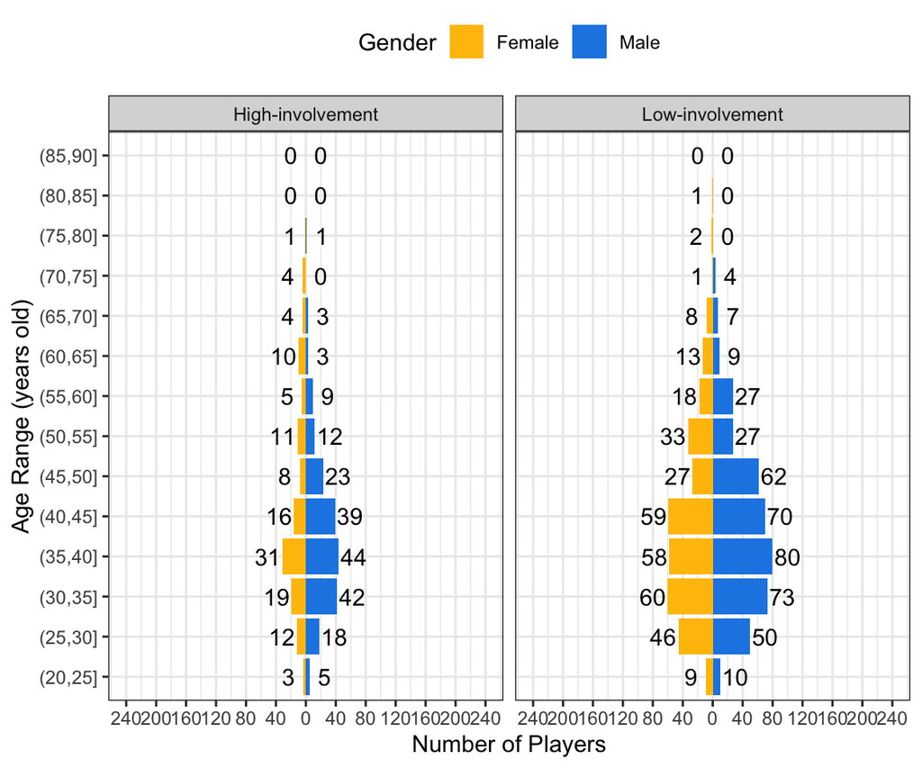

```r
age_pyramids <- ggplot(age_group, aes(age_range, age_count, fill=gender)) +
  # plot bars for males
  geom_col(data=filter(age_group, gender =="Male")) +
  # add the counts next to the bars
  geom_text(data=filter(age_group, gender =="Male"), aes(x=age_range, y = age_count, label = age_count), nudge_y = 20) +
  # plot bars for females, but flip it to the other side
  geom_col(data=filter(age_group, gender=="Female"), aes(y = age_count*(-1))) +
  # add the counts next to the bars
  geom_text(data=filter(age_group, gender =="Female"), aes(x=age_range, y = age_count*(-1), label = age_count), nudge_y = -20) +
  # for high-risk and low-risk group separately
  facet_wrap(~group) +
  # use colorblind-friendly color
  scale_fill_manual(values = color_values) +
  scale_color_manual(values = color_values) +
  labs(x = "Age Range (years old)", y = "Number of Players", fill = "Gender") +
  theme(legend.position = "top", legend.direction = "horizontal") +
  # adjust the tick labels on the y axis
  scale_y_continuous(limits = c(-240, 240), breaks=seq(-240,240,40), labels=abs(seq(-240,240,40))) +
  # flip the x and y axis
  coord_flip()

age_pyramids
```

```r
# save the figure in the fig folder
ggsave("figure/age_pyramids.png", age_pyramids)
```

## Number of sessions

In this section we account for the total number of sessions played across each involvement level (high and low) groups. We both, plot the distribution of the number of sessions played by the players in each involvement group as well as test the between-group comparison of the number of sessions played across the two groups.

```r
players_with_certain_sessions <- session_descriptive_df %>%
  # divide the total number of sessions into bins
  # note that the scale is transformed so that larger values are compressed
  mutate(n_session_bin = cut(n_sessions,
                             breaks = c(0:10, (2:10)*10, (2:10)*100, (2:5)*1000)),
         n_session_label = cut(n_sessions,
                             breaks = c(0:10, (2:10)*10, (2:10)*100, (2:5)*1000),
                             labels = 1:32)
  ) %>%
  # count the number of players with certain numbers of sessions
  count(group_levels, n_session_bin, n_session_label) %>%
  mutate(
    group = factor(group_levels,
                   labels = c("High-Involvement", "Low-Involvement")),
    n_session_label = as.numeric(n_session_label)
  )
```

Plot the histogram of the players

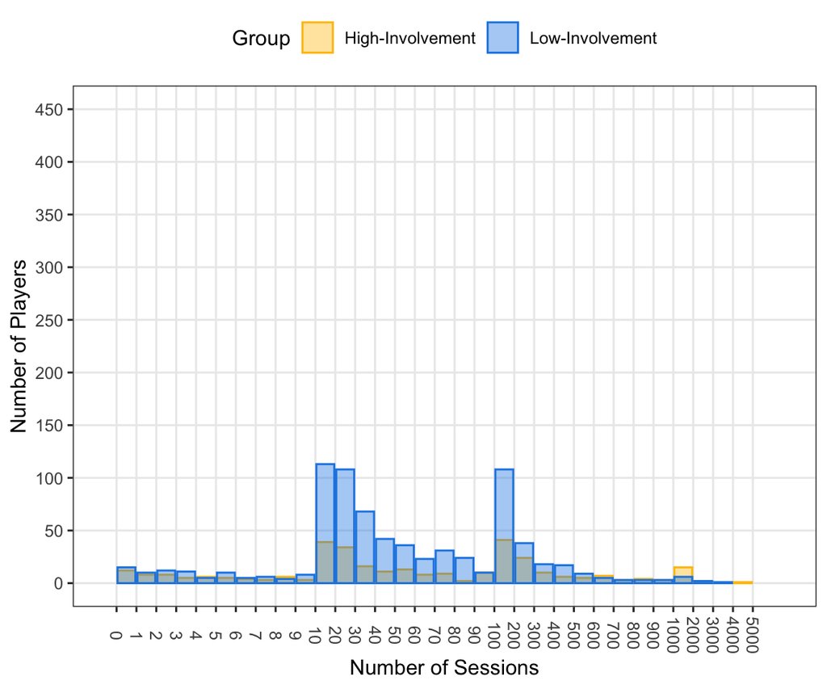

```r
# make a histogram for the total number of sessions
session_hist <- players_with_certain_sessions %>%
  ggplot(aes(n_session_label, n, fill = group, color = group)) +
  geom_bar(stat = "identity", alpha = 0.4, position = "identity") +
  scale_x_continuous(breaks = 0:32 + 0.5, # note that +0.5 to move the bars horizontally
                     labels = c(0:10, (2:10)*10, (2:10)*100, (2:5)*1000),
                     limits = c(0, 34)) +
  scale_y_continuous(breaks = (0:9) * 50,
                     labels = (0:9) * 50,
                     limits = c(0, 450)) +
  labs(x = "Number of Sessions", y = "Number of Players", fill = "Group", color = "Group") +
  # use colorblind-friendly color
  scale_fill_manual(values = color_values) +
  scale_color_manual(values = color_values) +
  theme(legend.position = "top", legend.direction = "horizontal",
        panel.grid.minor = element_blank(),
        axis.text.x=element_text(angle = -90, vjust = 0.5))

session_hist
```

```r
# save the figure in the fig folder
ggsave("figure/total_sessions.png", session_hist)
```

```r
# calculate the total numbers of sessions across all players
n_session_total <- sum(session_descriptive_df$n_sessions)

n_grp_levels <- session_descriptive_df %>%
  group_by(group_levels)%>%
  count(n_sessions)%>%
  summarise(total_session_num = sum(n_sessions))%>%
  ungroup()

# filter high-involvement players
n_session_HR <- session_descriptive_df%>%
  filter(group_levels == "High-involvement")

# filter low-involvement players
n_session_LR <- session_descriptive_df%>%
  filter(group_levels == "Low-involvement")

#Independent t-test

session_comp <- TES(n_session_HR$n_sessions, n_session_LR$n_sessions, paired = FALSE, conf = 0.95) # number of sessions

# combine and format the results
num_sess_comp <- session_comp %>%
  mutate(comp = c("Session number")) %>%
  select(comp, everything())

comp_formatted <- num_sess_comp %>%
  mutate(
    across(c(mean_x, sd_x, mean_y, sd_y, diff, lowerCI, upperCI), ~round(.x)),
    across(c(df, t, logBF), ~round(.x, digits = 1)),
    across(c(d, g), ~round(.x, digits = 3)))

# show the table
#kable(comp_formatted, caption = "Comparing numbers of sessions played between the two groups",
  #    booktabs = T, align = "c") %>%
#  scroll_box(width = "100%", height = "100%")
```

### Session Stakes

In this section we perform a between-group comparison of the amount of session stakes placed by the players across high- and low-involvement groups.

```r
# compare the high-involvement group and the low-involvement group
sess_stakes_HR <- filter(session_descriptive_df, group_levels == "High-involvement")
sess_stakes_LR <- filter(session_descriptive_df, group_levels == "Low-involvement")

# Independent t-tests
sess_stakes_max_comp    <- TES(sess_stakes_HR$stake_max, sess_stakes_LR$stake_max, paired = FALSE, conf = 0.95)
sess_stakes_min_comp    <- TES(sess_stakes_HR$stake_min, sess_stakes_LR$stake_min, paired = FALSE, conf = 0.95)
sess_stakes_mean_comp   <- TES(sess_stakes_HR$stake_mean, sess_stakes_LR$stake_mean, paired = FALSE, conf = 0.95)
sess_stakes_median_comp <- TES(sess_stakes_HR$stake_median, sess_stakes_LR$stake_median, paired = FALSE, conf = 0.95)

# combine all the above df's togather
stake_comp <- rbind(sess_stakes_max_comp, sess_stakes_min_comp, sess_stakes_mean_comp, sess_stakes_median_comp) %>%
  mutate(comp = c("Maximum stake", "Minimum stake", "Mean stake", "Median stake")) %>%
  select(comp, everything())

comp_formatted <- stake_comp %>%
  mutate(
    across(c(mean_x, sd_x, mean_y, sd_y, diff, lowerCI, upperCI), ~round(.x, digits = 2)),
    across(c(df, t, logBF), ~round(.x, digits = 3)),
    across(c(d, g), ~round(.x, digits = 3)))

# make a table
# kable(comp_formatted, caption = "Comparing the maximum, minimum, mean and median stake size between two groups",
  #    booktabs = T, align = "c") %>%
 # scroll_box(width = "100%", height = "100%")
```

### Session Net wins

In this section we compare the net session wins across the two groups. The net session wins are determined from the net session outcome (which is calculated as follows –: session win - session stake). If the net session outcome > 0 then the value corresponds to net session win i.e., net session outcome = net session win.

```r
# compare the high-involvement group and the low-involvement group
net_wins_HR <- filter(session_descriptive_df, group_levels == "High-involvement")
net_wins_LR <- filter(session_descriptive_df, group_levels == "Low-involvement")

# Independent t-tests
net_win_max_comp    <- TES(net_wins_HR$net_outcome_max_win , net_wins_LR$net_outcome_max_win , paired = FALSE, conf = .95) # net max wins
net_win_min_comp    <- TES(net_wins_HR$net_outcome_min_win, net_wins_LR$net_outcome_min_win, paired = FALSE, conf = .95) # net min wins
net_win_mean_comp   <- TES(net_wins_HR$net_outcome_mean_win, net_wins_LR$net_outcome_mean_win, paired = FALSE, conf = .95) # net mean wins
net_win_median_comp <- TES(net_wins_HR$net_outcome_median_win, net_wins_LR$net_outcome_median_win, paired = FALSE, conf = .95) # net median wins

# combine all the above df's togather

net_win_max_comp <- net_win_max_comp %>%
  mutate(comp = "Net Maximum win") %>%
  select(comp, everything())

net_win_min_comp <- net_win_min_comp %>%
  mutate(comp = "Net Minimum win") %>%
  select(comp, everything())

net_win_mean_comp <- net_win_mean_comp %>%
  mutate(comp = "Net Mean win") %>%
  select(comp, everything())

net_win_median_comp <- net_win_median_comp %>%
  mutate(comp = "Net Median win") %>%
  select(comp, everything())

net_win_comp <- rbind( net_win_max_comp,
                      net_win_min_comp, net_win_mean_comp,
                      net_win_median_comp)

comp_formatted <- net_win_comp %>%
  mutate(
    across(c(mean_x, sd_x, mean_y, sd_y, diff, lowerCI, upperCI), ~round(.x, digits = 2)),
    across(c(df, t, logBF), ~round(.x, digits = 3)),
    across(c(d, g), ~round(.x, digits = 3)))

# make a table
#kable(comp_formatted, caption = "Comparing the probability and net amount of sessions wins between two groups.",
   #   booktabs = T, align = "c") %>%
  #scroll_box(width = "100%", height = "100%")
```

### Session Net Losses

In this section we compare the net session losses across the two groups. The net session loss was determined from the net session outcome (which is calculated as follows –: session win - session stake). If the net session outcome < 0 then the value corresponds to net session loss i.e., net session outcome = net session loss. Note that net session outcomes < 0 i.e., net session losses were negative values. In order to get the correct magnitude estimates of net session losses for specific variables (e.g., max/min net loss) we have accounted for the absolute values of net session losses.

```r
# compare the high-involvement group and the low-involvement group
net_loss_HR <- filter(session_descriptive_df, group_levels == "High-involvement")
net_loss_LR <- filter(session_descriptive_df, group_levels == "Low-involvement")

# Independent t-tests
net_loss_max_comp    <- TES(net_loss_HR$net_outcome_max_loss , net_loss_LR$net_outcome_max_loss , paired = FALSE, conf = .95) # max net losses
net_loss_min_comp    <- TES(net_loss_HR$net_outcome_min_loss, net_loss_LR$net_outcome_min_loss, paired = FALSE, conf = .95) # min net losses
net_loss_mean_comp   <- TES(net_loss_HR$net_outcome_mean_loss, net_loss_LR$net_outcome_mean_loss, paired = FALSE, conf = .95) # mean losses
net_loss_median_comp <- TES(net_loss_HR$net_outcome_median_loss, net_wins_LR$net_outcome_median_loss, paired = FALSE, conf = .95) # median losses

# combine all the above df's togather

net_loss_max_comp <- net_loss_max_comp %>%
  mutate(comp = "Net Maximum loss") %>%
  select(comp, everything())

net_loss_min_comp <- net_loss_min_comp %>%
  mutate(comp = "Net Minimum loss") %>%
  select(comp, everything())

net_loss_mean_comp <- net_loss_mean_comp %>%
  mutate(comp = "Net Mean loss") %>%
  select(comp, everything())

net_loss_median_comp <- net_loss_median_comp %>%
  mutate(comp = "Net Median loss") %>%
  select(comp, everything())

net_loss_comp <- rbind( net_loss_max_comp,
                      net_loss_min_comp, net_loss_mean_comp,
                      net_loss_median_comp)

comp_formatted <- net_loss_comp %>%
  mutate(
    across(c(mean_x, sd_x, mean_y, sd_y, diff, lowerCI, upperCI), ~round(.x, digits = 2)),
    across(c(df, t, logBF), ~round(.x, digits = 3)),
    across(c(d, g), ~round(.x, digits = 3)))

# make a table
#kable(comp_formatted, caption = "Comparing the probability and net amount of session losses between two groups.",
  #    booktabs = T, align = "c") %>%
  #scroll_box(width = "100%", height = "100%")
```

### Break-even sessions

Next we want to compare the probability of a break-even session across high- and low-involvement groups.

```r
# compare the high-involvement group and the low-involvement group
brk_ev_HR <- filter(session_descriptive_df, group_levels == "High-involvement")
brk_ev_LR <- filter(session_descriptive_df, group_levels == "Low-involvement")

# Independent t-tests
brk_ev_prob <- TES(brk_ev_HR$break_even_prob, brk_ev_LR$break_even_prob , paired = FALSE, conf = .95) # break-even probability

# combine and format the results
brk_ev_sess <- brk_ev_prob %>%
  mutate(comp = c("Break-even probability")) %>%
  select(comp, everything())

comp_formatted <- brk_ev_sess %>%
  mutate(
    across(c(mean_x, sd_x, mean_y, sd_y, diff, lowerCI, upperCI), ~round(.x)),
    across(c(df, t, logBF), ~round(.x, digits = 1)),
    across(c(d, g), ~round(.x, digits = 3)))

# show the table
#kable(comp_formatted, caption = "Comparing probability of a break-even session between the two groups",
 #     booktabs = T, align = "c") %>%
 # scroll_box(width = "100%", height = "100%")
```

### Total spent

In the final play behaviour comparison we assess the total amount of money spent across the two groups.

```r
# compare the high-involvement group and the low-involvement group
total_spent_HR <- filter(session_descriptive_df, group_levels == "High-involvement")
total_spent_LR <- filter(session_descriptive_df, group_levels == "Low-involvement")

# Independent t-tests
total_spent_comp <- TES(total_spent_HR$total_spent, total_spent_LR$total_spent, paired = FALSE, conf = .95)

# combine and format the results
total_spent_comp <- total_spent_comp %>%
  mutate(comp = "Total spent") %>%
  select(comp, everything())

comp_formatted <- total_spent_comp %>%
  mutate(
    across(c(mean_x, sd_x, mean_y, sd_y, diff, lowerCI, upperCI), ~round(.x, digits = 2)),
    across(c(df, t, logBF), ~round(.x, digits = 1)),
    across(c(d, g), ~round(.x, digits = 3)))

# make a table
#kable(comp_formatted, caption = "Comparing the total amount of money spent between two groups.",
 #     booktabs = T, align = "c") %>%
 # scroll_box(width = "100%", height = "100%")
```

### Combine in one table

```r
# in the manuscript, we present all information in one table
# here we combine the separate tables into one
one_table <- rbind(num_sess_comp, stake_comp, net_win_comp,
                   net_loss_comp, brk_ev_sess, total_spent_comp)

# for brevity, we do not report results on maximum and minimum
#one_table <- one_table %>%
  #filter(!comp %in% c("Maximum stake", "Minimum stake", "Maximum win",
                     # "Minimum win", "Maximum loss", "Minimum loss"))

# correct the p values for multiple comparisons
one_table$p <- p.adjust(one_table$pt, method = "holm")

# do some formatting
one_table <- one_table %>%
  mutate(
    # rename comp into Parameter
    Parameter = comp,
    # for these variables, keep 1 digit after the decimal point
    across(c(mean_x:t, logBF), ~round(.x, digits = 1)),
    # for effect size g, keep 3 digits after the decimal point
    g = round(g, digits = 3),
    # report p values below .001 as < .001
    p = ifelse(p < .001, "<.001", sprintf("%.3f", round(p, digits = 3))),
    # combine mean and standard deviation for each group
    `High-involvement` = paste0(mean_x, " (", sd_x, ")"),
    `Low-involvement` = paste0(mean_y, " (", sd_y, ")")
    ) %>%
  # delete some redundant variables
  select(-c(comp:sd_y), -pt, -pw, -d, -BF) %>%
  select(Parameter, `High-involvement`, `Low-involvement`, diff, lowerCI, upperCI, df, t, p, logBF, g)

table_final_play_beh <- rempsyc::nice_table(one_table ,
           title = c("Table 2", "Comparison of play behaviour across high and low involvement group"))

#save the table
flextable::save_as_docx(table_final_play_beh, path = "table_final_play_beh.docx")




# show the table
kable(one_table, caption = "Comparing characteristics of play behavior between the two groups.",
      booktabs = T, align = "c") %>%
  scroll_box(width = "100%", height = "100%")
```

Comparing characteristics of play behavior between the two groups.

| Parameter | High-involvement | Low-involvement | diff | lowerCI | upperCI | df | t | p | logBF | g |
| --- | --- | --- | --- | --- | --- | --- | --- | --- | --- | --- |
| Session number | 218.9 (448.2) | 115.8 (233.3) | 103.1 | 51.3 | 154.9 | 398.8 | 3.9 | 0.001 | 9.3 | 0.260 |
| Maximum stake | 3394 (6304.8) | 1431.5 (2630.8) | 1962.5 | 1247.4 | 2677.6 | 370.9 | 5.4 | <.001 | 22.4 | 0.359 |
| Minimum stake | 8.9 (48.9) | 5.1 (11.1) | 3.7 | -1.7 | 9.1 | 336.2 | 1.4 | 0.529 | -0.7 | 0.090 |
| Mean stake | 232.5 (482.4) | 153.9 (306.7) | 78.6 | 21.4 | 135.7 | 437.5 | 2.7 | 0.057 | 2.4 | 0.180 |
| Median stake | 89.3 (167.6) | 75.2 (161.2) | 14.1 | -7.5 | 35.8 | 588.0 | 1.3 | 0.529 | -1.8 | 0.085 |
| Net Maximum win | 1409.9 (2907) | 537.6 (1402.9) | 872.3 | 538.8 | 1205.8 | 387.8 | 5.1 | <.001 | 18.7 | 0.342 |
| Net Minimum win | 29.3 (141.5) | 28.2 (109.9) | 1.1 | -16.2 | 18.5 | 495.5 | 0.1 | 0.899 | -2.6 | 0.008 |
| Net Mean win | 212.3 (364.7) | 134.6 (349) | 77.7 | 30.6 | 124.7 | 585.6 | 3.2 | 0.012 | 2.7 | 0.216 |
| Net Median win | 120 (241) | 85.8 (279.6) | 34.2 | 1.2 | 67.3 | 700.8 | 2.0 | 0.255 | -0.8 | 0.135 |
| Net Maximum loss | 464.6 (887.1) | 196.6 (339.9) | 268.0 | 167.9 | 368.0 | 363.2 | 5.3 | <.001 | 22.1 | 0.350 |
| Net Minimum loss | 4.1 (11.4) | 2.7 (6.8) | 1.4 | 0.1 | 2.8 | 424.0 | 2.1 | 0.255 | 0.6 | 0.140 |
| Net Mean loss | 47.1 (79.8) | 32.5 (51.3) | 14.6 | 5.1 | 24.0 | 440.2 | 3.0 | 0.024 | 3.7 | 0.201 |
| Net Median loss | 26.7 (45.1) | 21.7 (34.8) | 5.0 | -0.5 | 10.6 | 493.6 | 1.8 | 0.367 | -0.7 | 0.119 |
| Break-even probability | 1 (2.3) | 1.4 (4.5) | -0.4 | -0.8 | 0.1 | 1046.1 | -1.7 | 0.367 | -1.7 | 0.114 |
| Total spent | 82017 (265111.7) | 18809.3 (51005) | 63207.6 | 33960.9 | 92454.3 | 332.3 | 4.3 | <.001 | 16.5 | 0.283 |

# Time of re-return

Players may chase losses by re-returning faster following a last losing session as compared to a last winning session. In this set of exploratory analyses we assess if between-session chasing is observed following losing vs. winning sessions via time of re-engagement and whether high-involvement players re-return sooner than low-involvement players.

```r
# load data
session_gap_df <- read_csv(here("data", "processed_data","EDA", "Between_session", "session_gap_df.csv"))
```

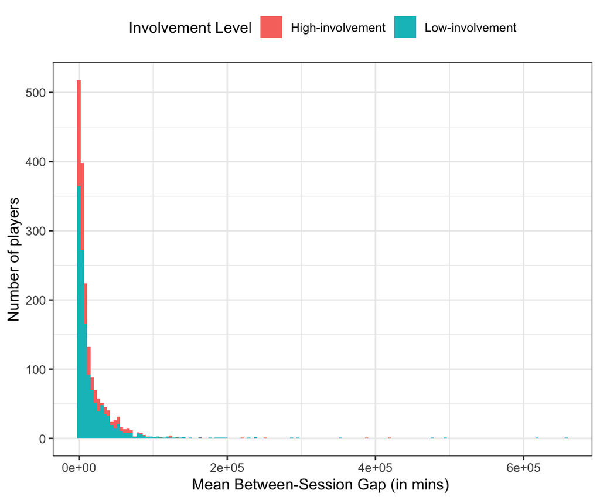

```r
#plot the distribution of the DV

mean_sess_gap_dist_overall <- ggplot(session_gap_df, aes(x = mean_session_gap, fill=group_levels)) +
                          geom_histogram(bins = 150) +
                          # add the title, x and y labels
                          labs(x = "Mean Between-Session Gap (in mins) ",
                               y = "Number of players") #+
                         # geom_density(aes(x = mean_session_gap, after_stat(count)))


mean_sess_gap_dist_overall  <- mean_sess_gap_dist_overall  + guides(fill = guide_legend(title="Involvement Level"))
mean_sess_gap_dist_overall
```

```r
# save the figure in the fig folder
ggsave("figure/mean_sess_gap_dist_overall.png", mean_sess_gap_dist_overall)
#the distribution is heavily right-skewed and thus not normally distributed
```

```r
session_gap_df$log_mean_sess_gap <- log(session_gap_df$mean_session_gap)
```

## Mixed ANOVA Model

```r
session_gap_anova <- aov_ez(id = "player_id",
                        dv = "mean_session_gap",
                        between = "group_levels",
                        within = "prev_outcome",
                        transformation = "log",
                        data = session_gap_df,
                        na.rm = TRUE)
session_gap_anova_table <- nice(session_gap_anova)

# format the anova table
session_gap_table <- session_gap_anova_table%>%
  mutate(
    Parameter = "Time to re-return (in mins))",
    Effect = c("Involvement level",
               "Prior Outcome", "Interaction: Involvement level * Prior Outcome"),
    # remove asterisks from the F values
    `F` = str_remove_all(`F`, "[*]"),
    # remove white space
    `F` = str_trim(`F`),
    p = `p.value`
  ) %>%
  #select(Parameter, Effect, df, MSE, `F`, ges, p)
  select(Effect, df, MSE, `F`, ges, p)


session_gap_table %>%
  kable() %>%
  kable_styling() %>%
  scroll_box(width = "100%", height = "400px")
```

| Effect | df | MSE | F | ges | p |
| --- | --- | --- | --- | --- | --- |
| Involvement level | 1, 915 | 3.48 | 0.44 | <.001 | .508 |
| Prior Outcome | 1, 915 | 1.89 | 403.86 | .135 | <.001 |
| Interaction: Involvement level * Prior Outcome | 1, 915 | 1.89 | 1.95 | <.001 | .163 |

## Plot

```r
sess_gap_summary <- session_gap_df %>%
  group_by(group_levels) %>%
  group_modify(~Rmisc::summarySEwithin(.x,
                                       measurevar = "log_mean_sess_gap",
                                       idvar = "player_id",
                                       withinvars = "prev_outcome")) %>%
  mutate(
    outcome = factor(prev_outcome, levels = c("loss", "win")),
    group = factor(group_levels, levels = c("High-Involvement", "Low-Involvement")),
                   labels = c("High-Involvement", "Low-Involvement"))
```

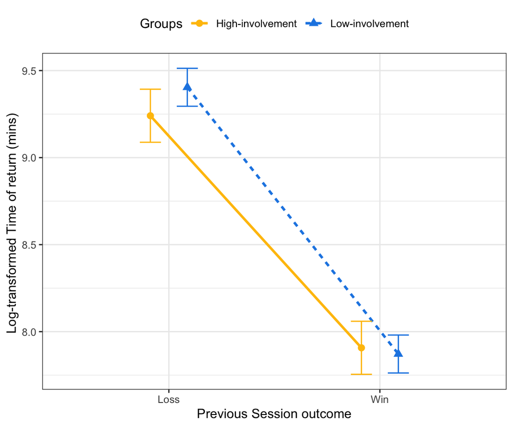

```r
session_gap_plot <- ggplot(sess_gap_summary,
                    aes(prev_outcome, log_mean_sess_gap, color = group_levels, shape = group_levels)) +
  geom_point(position = position_dodge(width = dodge_width), size = shape_size) +
  geom_line(aes(group = group_levels, linetype = group_levels), size = 1,
            position = position_dodge(width = dodge_width)) +
  geom_errorbar(aes(ymin = log_mean_sess_gap-ci, ymax = log_mean_sess_gap+ci), width = 0.2,
                position = position_dodge(width = dodge_width)) +
  # use colorblind-friendly color
  scale_color_manual(values=color_values) +
  scale_x_discrete(labels=c("loss" = "Loss", "win" = "Win")) +
  labs(x = "Previous Session outcome",
       y = "Log-transformed Time of return (mins) ")+
  theme(legend.position = "top", legend.direction = "horizontal") +
  labs(color = "Groups",
       shape = "Groups",
       linetype = "Groups")

session_gap_plot
```

```r
# save the figure in the fig folder
ggsave("figure/session_gap_plot.png", session_gap_plot)
```

## Pairwise comparison

```r
sess_gap_wide <- session_gap_df%>%
  pivot_wider(id_cols = c(group_levels, player_id),
              names_from = prev_outcome,
              values_from = log_mean_sess_gap)%>% #using the log transformed values
  mutate(diff_log_mean = loss - win)

## PAIRED T-TEST

# within-group comparison

comp_within <- sess_gap_wide %>%
  group_by(group_levels)%>%
  group_modify(~TES(.x$loss, .x$win, paired = TRUE))%>%
  mutate(d = dz, g = gav)%>%
  ungroup() %>%
  select(-group_levels, -dz, -gav, -dav)

## INDEPENDENT T-TEST

#between-group comparison

comp_between1 <- TES(filter(sess_gap_wide, group_levels == "High-involvement")$loss,
                     filter(sess_gap_wide, group_levels == "Low-involvement")$loss, paired = FALSE)

comp_between2 <- TES(filter(sess_gap_wide, group_levels == "High-involvement")$win,
                     filter(sess_gap_wide, group_levels == "Low-involvement")$win, paired = FALSE)

comp_between3 <- TES(filter(sess_gap_wide, group_levels == "High-involvement")$diff_log_mean,
                     filter(sess_gap_wide, group_levels == "Low-involvement")$diff_log_mean, paired = FALSE)


comp_between <- bind_rows(comp_between1, comp_between2,comp_between3)


comp_gap <- bind_rows(comp_within, comp_between)%>%
  mutate(
    Comparison = c("High-Loss vs. High-Win",
                   "Low-Loss vs. Low-Win",
                   "High-Loss vs. Low-Loss",
                   "High-Win vs. Low-Win",
                   "(High-Loss - High-Win) vs. (Low-Loss - Low-Win)"),pt = p.adjust(pt, method = "holm"))

comp_gap <- comp_gap%>%
  mutate(
    across(mean_x:upperCI, ~round(.x, digits = 2)),
    across(c(d,g), ~round(.x, digits = 3)),
    t = round(t, digits = 1),
    df = round(df, digits = 1),
    p = ifelse(pt <.001, "<.001", sprintf("%.3f", round(pt, digits = 3))),
    logBF = round(logBF, digits = 2)
  )%>%
  select(Comparison, mean_x:t, p, logBF, g)


comp_gap %>%
  kable() %>%
  kable_styling() %>%
  scroll_box(width = "100%", height = "400px")
```

| Comparison | mean_x | sd_x | mean_y | sd_y | diff | lowerCI | upperCI | df | t | p | logBF | g |
| --- | --- | --- | --- | --- | --- | --- | --- | --- | --- | --- | --- | --- |
| High-Loss vs. High-Win | 9.24 | 1.33 | 7.91 | 1.82 | 1.33 | 1.12 | 1.55 | 259.0 | 12.2 | <.001 | 55.42 | 0.846 |
| Low-Loss vs. Low-Win | 9.40 | 1.17 | 7.87 | 2.03 | 1.53 | 1.38 | 1.69 | 656.0 | 19.5 | <.001 | 146.45 | 0.957 |
| High-Loss vs. Low-Loss | 9.24 | 1.33 | 9.40 | 1.17 | -0.16 | -0.35 | 0.02 | 425.2 | -1.7 | 0.251 | -0.85 | 0.127 |
| High-Win vs. Low-Win | 7.91 | 1.82 | 7.87 | 2.03 | 0.04 | -0.23 | 0.31 | 527.9 | 0.3 | 0.796 | -2.47 | 0.019 |
| (High-Loss - High-Win) vs. (Low-Loss - Low-Win) | 1.33 | 1.77 | 1.53 | 2.01 | -0.20 | -0.46 | 0.07 | 537.8 | -1.5 | 0.280 | -1.55 | 0.108 |